# 維度縮減

Lin

2019/11/19

```r
data("USArrests")
library(tidyverse)  # data manipulation and visualization
library(gridExtra)  # plot arrangement
```

## PCA 主成份分析

- 目的為使用較少的變數來解釋最多的變異
- 當遇上大量變數時，可以透過主成份分析將資料維度有效縮減，以利後續資料探勘與分析工作
- 我們希望透過主成份分析來達成：運用最少的代表性資料維度來有效摘要大部分的資料資訊或變異（能捕捉到越多資料變異越好）

#### principal components analysis 主成份分析計算

- 假設我們的dataset由n個觀測值和p個維度所組成，而主成份分析(PCA)所找出的維度將是p個維度的線性組合
- 第一個主成份$Z_{1}$到第p個主成份$Zp$可透過以下公式來表示：
  $$Z_1 = \phi_{11}*X_1+\phi_{21}*X_2 + ... +\phi_{p1}$$
  ….
  $$Z_p = \phi_{p1}*X_1+\phi_{2p}*X_2 + ... + \phi_{pp}$$
  其中，
- $\sum_{ij}\phi_{ij}^2 = 1$ ，表示各主成分由不同比重的原始維度所組成
- 每個主成分的$\phi_{ij}$都是互相垂直的向量(即$\phi_1 \perp \phi_2 ... \perp \phi_p$)

我們可以使用線性代數的方法來計算每一個主成分的向量:

- 資料標準化
- 計算個原始維度兩兩間的共變異矩陣
- 算共變異矩陣的特徵值(eigenvalues)與特徵向量(eigenvectors)
- 萃取主成分

### 資料介紹

1973年美國50個州中的居民因襲擊，謀殺和強姦而被捕的人數(單位：十萬人)。此外，還有居住在城市地區的人口百分比。

```r
head(USArrests, 10)
```

```
##             Murder Assault UrbanPop Rape
## Alabama       13.2     236       58 21.2
## Alaska        10.0     263       48 44.5
## Arizona        8.1     294       80 31.0
## Arkansas       8.8     190       50 19.5
## California     9.0     276       91 40.6
## Colorado       7.9     204       78 38.7
## Connecticut    3.3     110       77 11.1
## Delaware       5.9     238       72 15.8
## Florida       15.4     335       80 31.9
## Georgia       17.4     211       60 25.8
```

### STEP1 : 資料維度標準化

主成份分析的第一步就是進行資料的標準化，標準化的好處是，可以消除不同指標間的單位度量衡差異。 待分析出不同主成份後，可以互相比較不同主成份間的平均值

scale的方式就是 (x – mean(x)) / sd(x)

```r
scaled_df <- apply(USArrests, 2, scale)
head(scaled_df)
```

```
##          Murder   Assault   UrbanPop         Rape
## [1,] 1.24256408 0.7828393 -0.5209066 -0.003416473
## [2,] 0.50786248 1.1068225 -1.2117642  2.484202941
## [3,] 0.07163341 1.4788032  0.9989801  1.042878388
## [4,] 0.23234938 0.2308680 -1.0735927 -0.184916602
## [5,] 0.27826823 1.2628144  1.7589234  2.067820292
## [6,] 0.02571456 0.3988593  0.8608085  1.864967207
```

### STEP 2: 我們可以使用cov()函數來計算兩兩變數的共變異數矩陣𝑝×𝑝如下。

```r
arrests.cov <- cov(scaled_df)
arrests.cov
```

```
##              Murder   Assault   UrbanPop      Rape
## Murder   1.00000000 0.8018733 0.06957262 0.5635788
## Assault  0.80187331 1.0000000 0.25887170 0.6652412
## UrbanPop 0.06957262 0.2588717 1.00000000 0.4113412
## Rape     0.56357883 0.6652412 0.41134124 1.0000000
```

### STEP 3 :計算矩陣的特徵值(eigen values)與特徵向量(eigen vectors)。其中eigen()函數產出的物件包含兩部分：

- $values：排序過後的特徵值
- $vectors：對應不同特徵值的特徵向量

```r
arrests.eigen <- eigen(arrests.cov)
arrests.eigen
```

```
## eigen() decomposition
## $values
## [1] 2.4802416 0.9897652 0.3565632 0.1734301
##
## $vectors
##            [,1]       [,2]       [,3]        [,4]
## [1,] -0.5358995  0.4181809 -0.3412327  0.64922780
## [2,] -0.5831836  0.1879856 -0.2681484 -0.74340748
## [3,] -0.2781909 -0.8728062 -0.3780158  0.13387773
## [4,] -0.5434321 -0.1673186  0.8177779  0.08902432
```

### STEP 4: 我們將萃取首兩大主成分1和主成分2作為我們說明的例子

```r
(phi <- arrests.eigen$vectors[,1:2])
```

```
##            [,1]       [,2]
## [1,] -0.5358995  0.4181809
## [2,] -0.5831836  0.1879856
## [3,] -0.2781909 -0.8728062
## [4,] -0.5434321 -0.1673186
```

因為R計算的特徵向量預設為指向負值，且我們知道特徵向量是獨特的值。只要是在同一方向上，不管是正向還是負向純量縮放，都是相同的。所以我們將特徵向量乘上純量-1。

```r
phi <- -phi
row.names(phi) <- c("Murder", "Assault", "UrbanPop", "Rape")
colnames(phi) <- c("PC1", "PC2")
phi
```

```
##                PC1        PC2
## Murder   0.5358995 -0.4181809
## Assault  0.5831836 -0.1879856
## UrbanPop 0.2781909  0.8728062
## Rape     0.5434321  0.1673186
```

檢視以上萃取的主成分向量，我們可以做出以下推論：  
- 主成分1(PC1): 代表各大犯罪（包含謀殺、突擊、強姦）的犯罪發生率因子  
- 主成分2(PC2): 代表為都市化水平因子  
- 我們將各觀測值投影到各主成分向量上，並計算各觀測值的各主成分分數(principal component scores)

```r
# Calculate Principal Components scores
PC1 <- as.matrix(scaled_df) %*% phi[,1] # %*% 表示矩陣乘法，此處為nxp矩陣乘上px1的向量，得到nx1的向量。
PC2 <- as.matrix(scaled_df) %*% phi[,2]

# Create data frame with Principal Components scores
PC <- data.frame(State = row.names(USArrests), PC1, PC2)
head(PC)
```

```
##        State        PC1        PC2
## 1    Alabama  0.9756604 -1.1220012
## 2     Alaska  1.9305379 -1.0624269
## 3    Arizona  1.7454429  0.7384595
## 4   Arkansas -0.1399989 -1.1085423
## 5 California  2.4986128  1.5274267
## 6   Colorado  1.4993407  0.9776297
```

#### 接著，我們將各國對應的主成分維度繪製成二維的平面圖

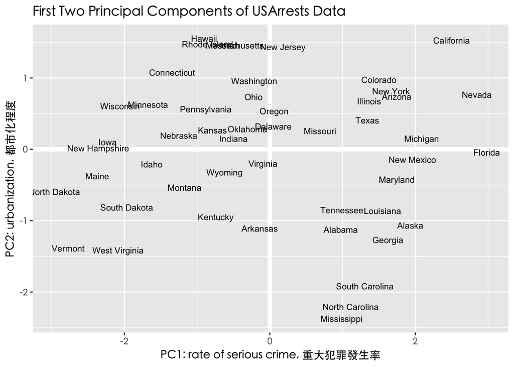

```r
par(family="黑體-繁 中黑")
ggplot(PC, aes(PC1, PC2)) +
  modelr::geom_ref_line(h = 0) +
  modelr::geom_ref_line(v = 0) +
  geom_text(aes(label = State), size = 3) +
  xlab("PC1: rate of serious crime, 重大犯罪發生率") +
  ylab("PC2: urbanization, 都市化程度") +
  ggtitle("First Two Principal Components of USArrests Data")+
  theme(text=element_text(family="黑體-繁 中黑"))
```

- 在PC1重大犯罪率維度上，Florida, Navada,California具有高重大犯罪率，而NorthDakota,Vermont的重大犯罪率則較低。
- 在PC2都市化程度維度上，Hawaii, New Jersey為高度都市化城市，而North California, Mississippi的都市化程度則較低。
- 而接近中心點的城市如Indiana, Virginia則表示在兩維度表現皆為平均值。

### 萃取主成分

透過以上計算過程我們能夠產出p個主成分向量，但是卻會有以下疑問：  
- 該如何決定萃取的主成分數目？ - 萃取的主成分又構成資料變異的多少比例？  
現在要介紹常用的指標PVE(The Proportion of Variance Explained)以及以利用該指標所繪出的資訊曲線圖，來輔助我們判斷每一個主成分解釋變異比例以及合適的萃取數。

#### The Proportion of Variance Explained (PVE)

第m個主成分解釋的變異量佔比計算公式如下：
$$PVE = \sum_{i=1}^n(\sum_{j=1}^p\phi_{jm}*x_{ij})^2 / \sum_{j =1}^p\sum_{i = 1}^mx_{ij}^2$$
即為第m個主成分的特徵值除上所有主成分特徵值加總。

```r
PVE <- arrests.eigen$values / sum(arrests.eigen$values)
round(PVE, 2)
```

```
## [1] 0.62 0.25 0.09 0.04
```

- 從上面計算結果，我們可知第一個主成分解釋變異佔比為62%，第二主成分解釋變異占比為25%。而首兩個主成分總解釋變異便佔了87%
- 我們可繪出各主成分所對應的解釋變異佔比以及累積佔比圖

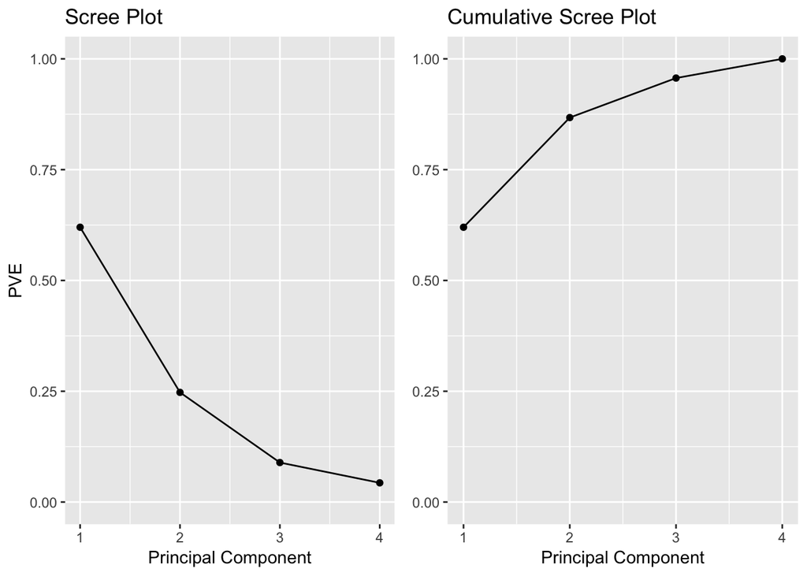

```r
# PVE (aka scree) plot
PVEplot <-
  qplot(c(1:4), PVE) +
  geom_line() +
  xlab("Principal Component") +
  ylab("PVE") +
  ggtitle("Scree Plot") +
  ylim(0, 1)


# Cumulative PVE plot
cumPVE <-
  qplot(c(1:4), cumsum(PVE)) +
  geom_line() +
  xlab("Principal Component") +
  ylab(NULL) +
  ggtitle("Cumulative Scree Plot") +
  ylim(0,1)

grid.arrange(PVEplot, cumPVE, ncol = 2)
```

#### 決定主成分萃取數

會視不同的分析目的和情形而定。一般來說，會根據每個主成分解釋變異百分比變化圖或累積圖，找出解釋絕大部分變異的最少主成分，約為線條出現轉折點處。比如說根據累積圖（上圖右），我們發現第三和第四主成分解釋的變異都有限，不如前兩個主成分，因此我們挑選解釋變異佔比前兩大主成分，兩主成分總構成約87%的變異

### R語言內建的PCA函數

在前面幾個步驟，我們為了熟悉主成分的計算邏輯，手動計算資料的共變異矩陣與矩陣對應的特徵值與特徵向量，但並不適合複雜的PCA運算。這邊將介紹一個R簡化PCA運算常用的套件: stats套件中的prcomp()函數。

prcomp()函數可以被用來快速處理上述幾個PCA相關運算。幾個重要參數包括：

- center: 預設值為TRUE。表示將資料平均值置中為0
- scale: 預設值為TRUE。表示將資料標準差壓縮為1

```r
pca_result <- prcomp(x = USArrests, center = TRUE, scale = TRUE)
pca_result
```

```
## Standard deviations (1, .., p=4):
## [1] 1.5748783 0.9948694 0.5971291 0.4164494
##
## Rotation (n x k) = (4 x 4):
##                 PC1        PC2        PC3         PC4
## Murder   -0.5358995  0.4181809 -0.3412327  0.64922780
## Assault  -0.5831836  0.1879856 -0.2681484 -0.74340748
## UrbanPop -0.2781909 -0.8728062 -0.3780158  0.13387773
## Rape     -0.5434321 -0.1673186  0.8177779  0.08902432
```

```r
names(pca_result)
```

```
## [1] "sdev"     "rotation" "center"   "scale"    "x"
```

sdev: 表示每個主成分的標準差

```r
pca_result$sdev
```

```
## [1] 1.5748783 0.9948694 0.5971291 0.4164494
```

rotation: 每個主成分的向量。也因為R預設特徵向量指向負向，我們調整將特徵向量乘上純量-1。經調整後，便和我們先前手動計算的結果相同了

```r
pca_result$rotation
```

```
##                 PC1        PC2        PC3         PC4
## Murder   -0.5358995  0.4181809 -0.3412327  0.64922780
## Assault  -0.5831836  0.1879856 -0.2681484 -0.74340748
## UrbanPop -0.2781909 -0.8728062 -0.3780158  0.13387773
## Rape     -0.5434321 -0.1673186  0.8177779  0.08902432
```

```r
pca_result$rotation <- -pca_result$rotation
pca_result$rotation
```

```
##                PC1        PC2        PC3         PC4
## Murder   0.5358995 -0.4181809  0.3412327 -0.64922780
## Assault  0.5831836 -0.1879856  0.2681484  0.74340748
## UrbanPop 0.2781909  0.8728062  0.3780158 -0.13387773
## Rape     0.5434321  0.1673186 -0.8177779 -0.08902432
```

```r
pca_result$center
```

```
##   Murder  Assault UrbanPop     Rape
##    7.788  170.760   65.540   21.232
```

```r
pca_result$scale
```

```
##    Murder   Assault  UrbanPop      Rape
##  4.355510 83.337661 14.474763  9.366385
```

另外，我們也可以從結果取得每一個國家（每一個觀察值）的主成分分數。（但記得，如同特徵向量之處理，主成分分數也要乘上純量-1 !!!!)

```r
pca_result$x <- - pca_result$x
head(pca_result$x)
```

```
##                   PC1        PC2         PC3          PC4
## Alabama     0.9756604 -1.1220012  0.43980366 -0.154696581
## Alaska      1.9305379 -1.0624269 -2.01950027  0.434175454
## Arizona     1.7454429  0.7384595 -0.05423025  0.826264240
## Arkansas   -0.1399989 -1.1085423 -0.11342217  0.180973554
## California  2.4986128  1.5274267 -0.59254100  0.338559240
## Colorado    1.4993407  0.9776297 -1.08400162 -0.001450164
```

如果要印出二維主成分圖，可以使用stat套件中的biplot()函數。常用參數包括：  
- choice: 預設為使用第一和第二欄來繪製(choice = 1:2)。如果想要調整繪製x,y軸，比如說繪製第三和第四主成分則可將參數設定為choices = 3:4

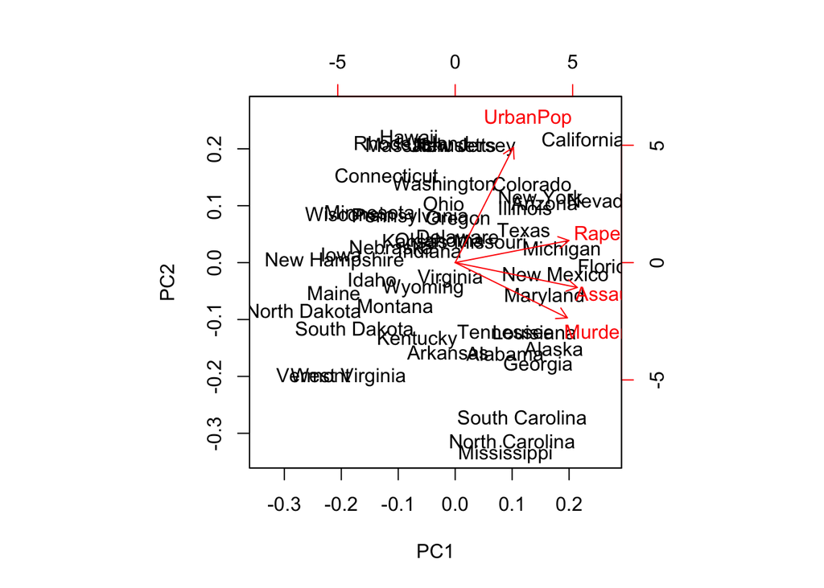

```r
biplot(x = pca_result) #default為第一和第二欄
```

跟先前比較不同之處，圖中的標記的紅色向量分別表示各變數對主成分的作用的方向。

另外，我們也可以算出每個主成分解釋變異量

```r
(VE <- pca_result$sdev^2)
```

```
## [1] 2.4802416 0.9897652 0.3565632 0.1734301
```

```r
PVE <- VE / sum(VE)
round(PVE, 2)
```

```
## [1] 0.62 0.25 0.09 0.04
```

### PCA總結

- 主成分分析的應用非常廣泛，不僅可搭配迴歸、羅吉斯回歸、分群演算法一併使用，來有效降低維度。
- 或是在查看分群結果時，我們可透過fviz_cluster()或plot.kmeans()函數將多維資料呈現在二維平面用的即是主成分分析方法

## SPCA 稀疏主成份分析

- PCA的分析結果難以解釋，因為每一個主成分都是原始的所有變數的線性組合，每一個主成分表達的特徵很難看出來。
- 2006年H Zou, T Hastie和 R Tibshirani發表的“Sparse principal component analysis”提出解決這問題的方法，即稀疏主成分分析(SPCA)。論文中首先證明了主成分分析的求解可以被表示為一個回歸形式的最優化問題，在這最優化問題中引入lasso懲罰項，使不重要的loadings變0（變數稀疏化），因此主成分中主要的部分就凸顯出來，更加容易解釋。

```r
library(nsprcomp)
spca <- nscumcomp(USArrests, 3, nneg = T, scale = T)
summary(spca)
```

```
## Importance of components:
##                           PC1     PC2     PC3
## Standard deviation     1.5178 0.48245 0.26127
## Proportion of Variance 0.8844 0.08936 0.02621
## Cumulative Proportion  0.8844 0.97379 1.00000
```

```r
#k：非 0 係數個數，通常是「每個主成份期待非 0 係數個數」x 變數個數
#nneg：是否希望所有係數都非負，TRUE 代表有非負限制
```